# 浅野ゼミナール 夏合宿 2018

2018年度の浅野ゼミ夏合宿は、9/7~9/9の二泊三日の日程で静岡県伊東市にある山喜旅館にて行われました。

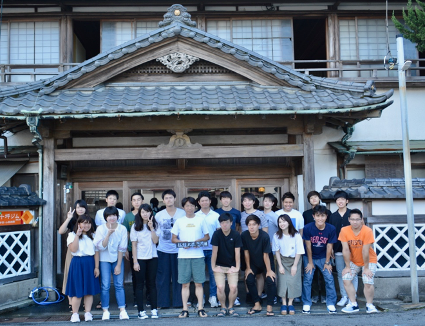

伊東市山木旅館前にて記念撮影

今回の夏合宿では、3・4年生はゼミ論文のリサーチ・デザインに関する中間報告、2年生はビブリオバトルを行いました。1日目と2日目は論文の中間報告を行いました。各々、前期のゼミの授業で先生から指摘された点や新しい論文案を探し、夏休みにリサーチ・デザインを組み立て、発表しました。自分では気づかない発想や新たな視点など、様々な助言を頂き、「次にどうしていけばいいのか」「どこがいけなかったのか」という課題が明確になりました。

[figure not shown]

ゼミ論のリサーチデザインを発表する3年生

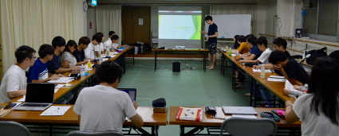

ゼミ論のリサーチデザインを発表する４年生

2日目の午後からは、2年生によるビブリオバトルを行いました。自ら選んできた本の紹介を制限時間５分の中で行うものです。その発表を聞いた人の心を掴み、「その本が読みたい」と思わせることが大切です。その中で今回のビブリオ勝者二人は上手く自分の感想を交えながら魅力を伝えることができたように思います。

[figure not shown]

ビブリオウィナーの一人、伊藤君

[figure not shown]

ビブリオウィナーの一人、遠藤君

２日目の夜は懇親会が行われました。ビンゴ大会等を通し、学年の垣根を超え和気藹々と楽しい時間が過ごせました。

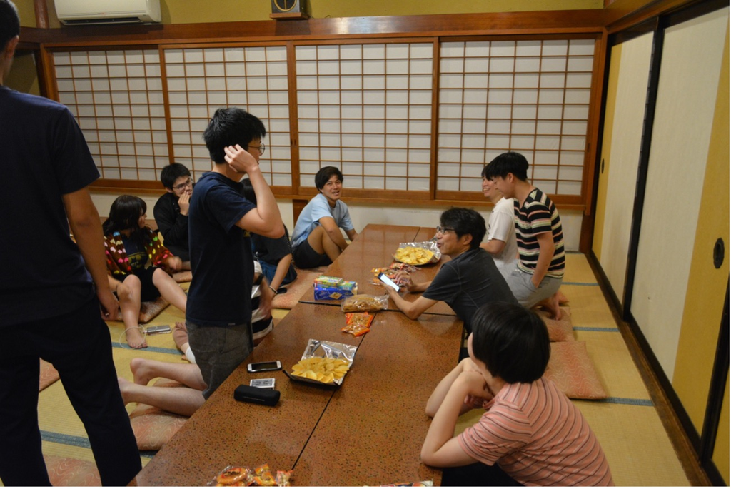

懇親会の一コマ

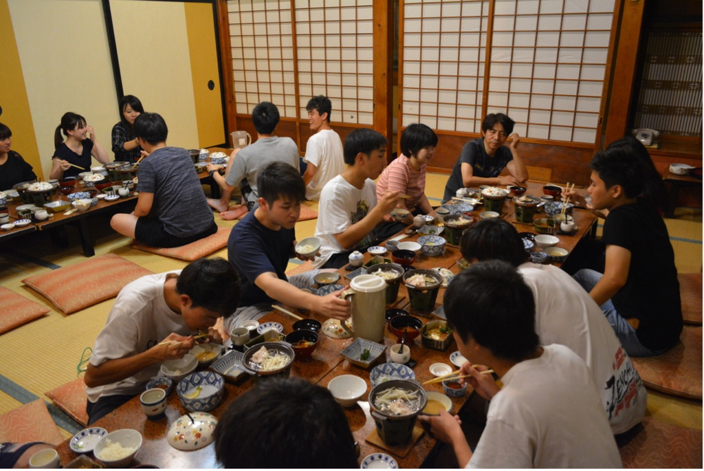

夕飯の様子

[figure not shown]

ビンゴになった堀井君

[figure not shown]

ビンゴになった岸沢さん

人前で発表をする機会が普段少ない私にとってこのような機会は貴重であり、「どのようにしたら人に伝わるのか」就活を前に良い体験になりました。 （文責：政経学部 経済学科 3年 藤枝郁成）

### 参加者の感想

#### 政経学部 法律政治学科 3年 滝瀬友優貴

今年から浅野ゼミに入った私は夏合宿に初めて参加しました。論文を書き上げていく上で、とても勉強になる合宿でした。発表を行い、浅野先生やゼミ生からコメントをいただいたことで、今後への課題を多く見つけることができ、とても有意義な時間を過ごすことができました。

#### 政経学部 法律政治学科 2年 関 駿介

3・4年生の論文発表を見て、自分は前に出て話すことが苦手で先輩方のようにまとめて上手く話せるようになりたいと思いました。みんなと仲良くなれて楽しかったです。